# MonteCarlo 02

9 actividades, 6 rutas, distribución triangular

# Enunciado

Considere el proyecto cuyo cuadro de prelaciones y estimaciones optimista, más probable y pesimista (en semanas) se adjunta. Suponga que la duración de cada actividad sigue una distribución triangular de parámetros $(a, m, b)$.

1. Dibuje el grafo PERT, construya la matriz de caminos y calcule la duración del proyecto con las duraciones medias.

2. Genere 10000 réplicas de las duraciones de las actividades y, con la matriz de caminos, obtenga la duración del proyecto en cada una. Calcule su media, desviación típica y percentiles 5, 50 y 95.

3. Calcule la probabilidad de terminar en 33 semanas o menos y la duración que puede comprometerse con un 90% de probabilidad. Compare con la aproximación normal por el camino crítico y explique las diferencias.

4. Calcule el índice de criticidad de cada ruta y de cada actividad. ¿Qué actividad no crítica convendría vigilar?

Tabla 1: Cuadro de datos del enunciado

| activity | predecessor | a | m | b |
| --- | --- | --- | --- | --- |
| A | --- | 1 | 4 | 7 |
| B | --- | 5 | 6 | 7 |
| C | --- | 3 | 6 | 6 |
| D | A,B,C | 3 | 6 | 6 |
| E | D | 6 | 6 | 9 |
| F | E | 3 | 3 | 6 |
| G | F | 1 | 3 | 5 |
| H | E | 7 | 8 | 9 |
| I | H | 4 | 5 | 9 |

El proyecto corresponde a la organización de un congreso científico; las actividades son las siguientes (las duraciones del cuadro están en semanas).

Tabla 2: Descripción de las actividades

|  | Descripción |
| --- | --- |
| A | Definición del programa y fechas |
| B | Reserva de la sede |
| C | Convocatoria de comunicaciones |
| D | Página web e inscripciones |
| E | Contratación de ponentes invitados |
| F | Revisión de los trabajos recibidos |
| G | Elaboración del programa definitivo |
| H | Contratación de catering y viajes |
| I | Edición del libro de actas |

# Resolución

Para la distribución triangular la media es $(a + m + b)/3$ y la varianza $(a^2 + m^2 + b^2 - ab - am - bm)/18$.

| activity | predecessor | a | m | b | duration | variance | standard_deviation |
| --- | --- | --- | --- | --- | --- | --- | --- |
| A | --- | 1 | 4 | 7 | 4 | 1.500000 | 1.224745 |
| B | --- | 5 | 6 | 7 | 6 | 0.166667 | 0.408248 |
| C | --- | 3 | 6 | 6 | 5 | 0.500000 | 0.707107 |
| D | A,B,C | 3 | 6 | 6 | 5 | 0.500000 | 0.707107 |
| E | D | 6 | 6 | 9 | 7 | 0.500000 | 0.707107 |
| F | E | 3 | 3 | 6 | 4 | 0.500000 | 0.707107 |
| G | F | 1 | 3 | 5 | 3 | 0.666667 | 0.816497 |
| H | E | 7 | 8 | 9 | 8 | 0.166667 | 0.408248 |
| I | H | 4 | 5 | 9 | 6 | 1.166667 | 1.080123 |

## Apartado 1

1. Dibuje el grafo PERT, construya la matriz de caminos y calcule la duración del proyecto con las duraciones medias.

Cálculo de los tiempos tempranos y tardíos de los sucesos y de las holguras totales paso a paso. El primer paso muestra el grafo resuelto; a partir del siguiente se calcula desde el principio (avance con los botones):

paso 0 de 31

[figure not shown]

Figura 1: Grafo PERT con las duraciones medias

Tabla 3: Matriz de caminos

[figure not shown]

👆 **Interactivo:** haz clic en una fila de la matriz para resaltar en el grafo las actividades y los nodos de esa ruta (otro clic la deselecciona).

|  | duración media | varianza |
| --- | --- | --- |
| Route_1 | 23 | 3.666667 |
| Route_2 | 30 | 3.833333 |
| Route_3 | 25 | 2.333333 |
| Route_4 | 32 | 2.500000 |
| Route_5 | 24 | 2.666667 |
| Route_6 | 31 | 2.833333 |

Con las duraciones medias el proyecto dura 32 semanas; la ruta crítica es Route_4 y su desviación típica 1.581.

## Apartado 2

2. Genere 10000 réplicas de las duraciones de las actividades y, con la matriz de caminos, obtenga la duración del proyecto en cada una. Calcule su media, desviación típica y percentiles 5, 50 y 95.

Cada réplica es un vector de duraciones generado con la distribución triangular de mínimo $a$, moda $m$ y máximo $b$ (cuando $a = m = b$ la duración es fija).

Tabla 4: Medias y desviaciones típicas muestrales frente a las teóricas

|  | A | B | C | D | E | F | G | H | I |
| --- | --- | --- | --- | --- | --- | --- | --- | --- | --- |
| media teórica | 4.00 | 6.00 | 5.00 | 5.00 | 7.00 | 4.00 | 3.00 | 8.00 | 6.00 |
| media muestral | 4.01 | 6.00 | 5.00 | 4.99 | 6.99 | 4.00 | 3.01 | 8.00 | 5.99 |
| σ teórica | 1.22 | 0.41 | 0.71 | 0.71 | 0.71 | 0.71 | 0.82 | 0.41 | 1.08 |
| σ muestral | 1.22 | 0.41 | 0.71 | 0.71 | 0.71 | 0.71 | 0.82 | 0.41 | 1.08 |

La duración de cada ruta en cada réplica es el producto de las duraciones por la traspuesta de la matriz de caminos; la del proyecto, el máximo por filas.

|  | Route_1 | Route_2 | Route_3 | Route_4 | Route_5 | Route_6 | Proyecto |
| --- | --- | --- | --- | --- | --- | --- | --- |
| 0 | 23.54 | 32.81 | 25.38 | 34.66 | 24.65 | 33.93 | 34.66 |
| 1 | 23.43 | 28.50 | 25.86 | 30.93 | 25.47 | 30.54 | 30.93 |
| 2 | 25.97 | 30.13 | 26.91 | 31.06 | 26.33 | 30.48 | 31.06 |
| 3 | 19.80 | 25.35 | 24.34 | 29.89 | 23.42 | 28.98 | 29.89 |
| 4 | 20.70 | 31.50 | 23.48 | 34.28 | 22.45 | 33.25 | 34.28 |

Tabla 5: Descriptores de la duración simulada del proyecto

|  | count | mean | std | min | 5% | 50% | 95% | max |
| --- | --- | --- | --- | --- | --- | --- | --- | --- |
| Duración del proyecto | 10000.0 | 32.02 | 1.58 | 27.34 | 29.49 | 31.96 | 34.72 | 37.41 |

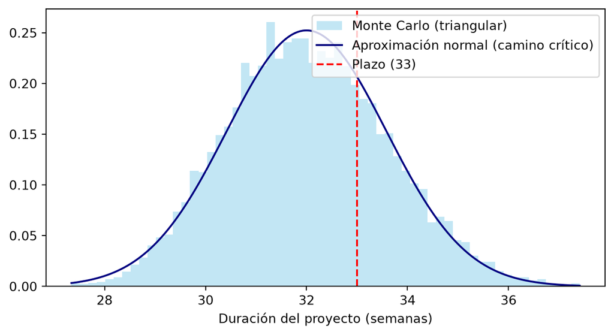

Figura 2: Distribución simulada de la duración frente a la aproximación normal

## Apartado 3

3. Calcule la probabilidad de terminar en 33 semanas o menos y la duración que puede comprometerse con un 90% de probabilidad. Compare con la aproximación normal por el camino crítico y explique las diferencias.

|  | Aproximación normal | Monte Carlo |
| --- | --- | --- |
| Duración media | 32.00 | 32.02 |
| Desviación típica | 1.58 | 1.58 |
| P(T ≤ 33) (%) | 73.65 | 73.33 |
| Duración para 90% | 34.03 | 34.11 |

La aproximación normal sólo mira la ruta crítica. En cada réplica, sin embargo, la duración del proyecto es el máximo de todas las rutas, y el máximo de varias variables aleatorias tiene una media mayor que cualquiera de ellas: las rutas casi críticas empujan la duración hacia arriba (*sesgo de fusión*). Por eso Monte Carlo da una duración media algo mayor y una probabilidad de cumplir el plazo algo menor: el método PERT clásico es optimista. La desviación típica simulada suele ser menor, porque cuando una ruta sale corta otra ocupa su lugar y la cola izquierda se recorta.

## Apartado 4

4. Calcule el índice de criticidad de cada ruta y de cada actividad. ¿Qué actividad no crítica convendría vigilar?

El índice de criticidad de una ruta es la fracción de réplicas en que es la más larga; el de una actividad, la fracción de réplicas en que pertenece a la ruta más larga.

Tabla 6: Índice de criticidad de las rutas

|  | actividades | duración media | criticidad (%) |
| --- | --- | --- | --- |
| Route_4 | B - D - E - H - I | 32 | 84.4 |
| Route_6 | C - D - E - H - I | 31 | 9.3 |
| Route_2 | A - D - E - H - I | 30 | 6.3 |
| Route_1 | A - D - E - F - G | 23 | 0.0 |
| Route_3 | B - D - E - F - G | 25 | 0.0 |
| Route_5 | C - D - E - F - G | 24 | 0.0 |

Tabla 7: Índice de criticidad de las actividades frente a su holgura total

|  | A | B | C | D | E | F | G | H | I |
| --- | --- | --- | --- | --- | --- | --- | --- | --- | --- |
| holgura total | 2.0 | 0.0 | 1.0 | 0.0 | 0.0 | 7.0 | 7.0 | 0.0 | 0.0 |
| criticidad (%) | 6.3 | 84.4 | 9.3 | 100.0 | 100.0 | 0.0 | 0.0 | 100.0 | 100.0 |

La librería hace el mismo cálculo de forma vectorizada: la sensibilidad empírica media de `monte_carlo` es precisamente el índice de criticidad de cada actividad.

|  | mean | std | q05 | q50 | q95 | min | max |
| --- | --- | --- | --- | --- | --- | --- | --- |
| τ | 32.02 | 1.58 | 29.49 | 31.96 | 34.72 | 27.34 | 37.41 |

|  | E | H | D | I | B | C | A | G | F |
| --- | --- | --- | --- | --- | --- | --- | --- | --- | --- |
| criticidad (%) según monte_carlo | 100.0 | 100.0 | 100.0 | 100.0 | 84.4 | 9.3 | 6.3 | 0.0 | 0.0 |

La actividad no crítica con mayor índice de criticidad es **C** (9.3 % de las réplicas en la ruta más larga, con holgura 1). El análisis determinista la da por holgada, pero un retraso pequeño la convierte en crítica: es la que conviene vigilar.